# Importing Libraries

# Final Model Performance Evaluation

```python
best_idx = np.argmax(evals_df['val_accuracy'])
best_model = models[best_idx]

best_model.summary()
evals_df.iloc[best_idx]
```

```
Model: "sequential_17"
```

```
┏━━━━━━━━━━━━━━━━━━━━━━━━━━━━━━━━━━━━━━┳━━━━━━━━━━━━━━━━━━━━━━━━━━━━━┳━━━━━━━━━━━━━━━━━┓
┃ Layer (type)                         ┃ Output Shape                ┃         Param # ┃
┡━━━━━━━━━━━━━━━━━━━━━━━━━━━━━━━━━━━━━━╇━━━━━━━━━━━━━━━━━━━━━━━━━━━━━╇━━━━━━━━━━━━━━━━━┩
│ embedding_17 (Embedding)             │ (None, 31, 50)              │       1,134,900 │
├──────────────────────────────────────┼─────────────────────────────┼─────────────────┤
│ lstm_16 (LSTM)                       │ (None, 32)                  │          10,624 │
├──────────────────────────────────────┼─────────────────────────────┼─────────────────┤
│ dense_17 (Dense)                     │ (None, 1)                   │              33 │
└──────────────────────────────────────┴─────────────────────────────┴─────────────────┘
```

```
 Total params: 3,436,673 (13.11 MB)
```

```
 Trainable params: 1,145,557 (4.37 MB)
```

```
 Non-trainable params: 0 (0.00 B)
```

```
 Optimizer params: 2,291,116 (8.74 MB)
```

```
embeddings_output_dim    50.000000
lstm_layer_units         32.000000
training_accuracy         0.716538
val_accuracy              0.807087
training_loss             0.549370
val_loss                  0.440175
Name: 12, dtype: float64
```

The best-performing model in terms of validation accuracy, is the LSTM model with trained embeddings of 50d, and 32 LSTM layer output dimension. The training accuracy is 71.6% and the validation accuracy is 80.7%.

```
238/238 ━━━━━━━━━━━━━━━━━━━━ 1s 2ms/step
```

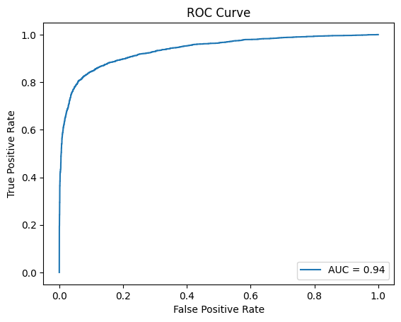

```python
pred_proba = best_model.predict(texts_seq_pad).reshape(-1)
actual = train['target']

fpr, tpr, thresholds = roc_curve(actual, pred_proba)
auc_score = auc(fpr, tpr)

plt.plot(fpr, tpr, label = 'AUC = ' + str(round(auc_score, 2)))
plt.xlabel('False Positive Rate')
plt.ylabel('True Positive Rate')
plt.title('ROC Curve')
plt.legend(loc = 'lower right')
plt.show()
```

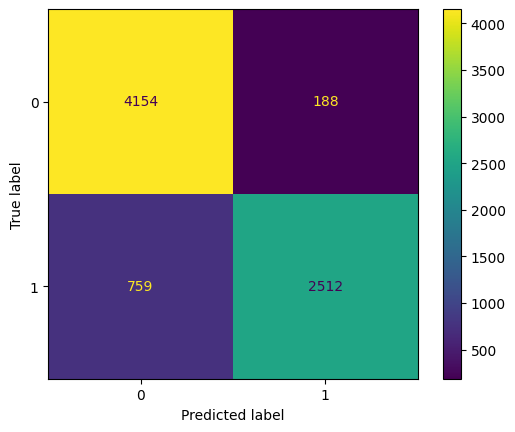

```python
pred = (pred_proba >= 0.5).astype(int)
cm = confusion_matrix(actual, pred)

ConfusionMatrixDisplay(cm).plot()
plt.show()
```

```python
tn = cm[0,0]
fp = cm[0,1]
fn = cm[1,0]
tp = cm[1,1]

print(f"Accuracy: {(tn+tp)/(tn+fp+fn+tp):.2f}")
print(f"Precision: {tp/(tp+fp):.2f}")
print(f"Recall: {tp/(tp+fn):.2f}")
```

```
Accuracy: 0.88
Precision: 0.93
Recall: 0.77
```

```python
texts_seq_pad.shape
```

```
(7613, 31)
```

# Conclusions

### Attempts to improve model performance with pre-trained embeddings was not successful

Using the GloVe pre-trained embeddings actually led to lower performance in terms of accuracy and loss metrics, even though there were less signs of overfitting than when using learned embeddings. This was surprising to me since pre-trained embeddings were trained on a much larger and comprehensive dataset than what's in our training data, and so should capture the true semantic relationship between words much better and help the model. It seems to be that using custom learned embeddings was better for this particular problem. It would be useful to try other pre-trained embeddings such as Word2Vec, and explore using pre-trained models such as BERT.

### Attempts to improve model performance with architecture changes was not successful

# Test Predictions

```python
test_texts = []

for text in test['text'].str.lower():
    test_texts.append(word_tokenize(text))

test_texts_seq = tz.texts_to_sequences(test_texts)

max_len = len(texts_seq_pad[0]) # match the max length of test text sequences to be the same as it was for training
test_texts_seq_pad = pad_sequences(test_texts_seq, maxlen = max_len, truncating = 'post')

test_texts_seq_pad.shape
```

```
(3263, 31)
```

```python
pred_proba = best_model.predict(test_texts_seq_pad).reshape(-1)
pred_proba.shape
```

```
102/102 ━━━━━━━━━━━━━━━━━━━━ 0s 2ms/step
```

```
(3263,)
```

```python
submission = pd.DataFrame({'id':test['id'], 'target':np.round(pred_proba).astype(int)})
submission.shape
```

```
(3263, 2)
```

```python
submission.head()
```

|  | id | target |
| --- | --- | --- |
| 0 | 0 | 0 |
| 1 | 2 | 0 |
| 2 | 3 | 1 |
| 3 | 9 | 0 |
| 4 | 11 | 1 |

```python
submission.to_csv('submission.csv', index = False)
```